# ML practice 2: Regression, logistic regression. ROC-curve, AUC

В прошлый раз мы вспомнили деревья решений для задачи классификации. А что в случае регрессии?

- Задача регрессии – это задача обучения с учителем или обучения без учителя?

Вспомним о модели линейной регрессии. Только на этот раз мы не будем внимательно изучать взаимосвязи переменных, а используем модель для предказания.

### Данные

Работаем с данными про цены на жилье в Бостоне

```r
library(MASS)
#?Boston
```

- `crim` per capita crime rate by town
- `zn` proportion of residential land zoned for lots over 25,000 sq.ft
- `indus` proportion of non-retail business acres per town
- `chas` Charles River dummy variable (= 1 if tract bounds river; 0 otherwise).
- `nox` nitrogen oxides concentration (parts per 10 million).
- `rm` average number of rooms per dwelling.
- `age` proportion of owner-occupied units built prior to 1940.
- `dis` weighted mean of distances to five Boston employment centres.
- `rad` index of accessibility to radial highways.
- `tax` full-value property-tax rate per $10,000.
- `ptratio` pupil-teacher ratio by town.
- `black` 1000(Bk - 0.63)^2 where Bk is the proportion of blacks by town.
- `lstat` lower status of the population (percent).
- `medv` median value of owner-occupied homes in $1000s.

```r
data(Boston)
pander::pandoc.table(head(Boston), split.tables=Inf)
```

| crim | zn | indus | chas | nox | rm | age | dis | rad | tax | ptratio | black | lstat | medv |
| --- | --- | --- | --- | --- | --- | --- | --- | --- | --- | --- | --- | --- | --- |
| 0.00632 | 18 | 2.31 | 0 | 0.538 | 6.575 | 65.2 | 4.09 | 1 | 296 | 15.3 | 396.9 | 4.98 | 24 |
| 0.02731 | 0 | 7.07 | 0 | 0.469 | 6.421 | 78.9 | 4.967 | 2 | 242 | 17.8 | 396.9 | 9.14 | 21.6 |
| 0.02729 | 0 | 7.07 | 0 | 0.469 | 7.185 | 61.1 | 4.967 | 2 | 242 | 17.8 | 392.8 | 4.03 | 34.7 |
| 0.03237 | 0 | 2.18 | 0 | 0.458 | 6.998 | 45.8 | 6.062 | 3 | 222 | 18.7 | 394.6 | 2.94 | 33.4 |
| 0.06905 | 0 | 2.18 | 0 | 0.458 | 7.147 | 54.2 | 6.062 | 3 | 222 | 18.7 | 396.9 | 5.33 | 36.2 |
| 0.02985 | 0 | 2.18 | 0 | 0.458 | 6.43 | 58.7 | 6.062 | 3 | 222 | 18.7 | 394.1 | 5.21 | 28.7 |

### Обучающая и тестовая выборки

Отделим 20% от датасета. Так же, как и для классификации, эта часть не будет использоваться для обучения модели, но на ней мы будем проверять (тестировать), насколько хороша наша модель.

```r
set.seed(6)
Boston.test.ind = sample(seq_len(nrow(Boston)), size = nrow(Boston)*0.2)
Boston.test = Boston[Boston.test.ind,]
Boston.train = Boston[-Boston.test.ind,]
```

Напомним, что задачу регрессии можно решать с помощью деревьев решений * в чем отличие регрессионных деревьев от классификационных?

Одна из особенностей регрессионных деревьев – в качестве предсказания используются всего несколько значений (средние по группам). Существуют и более гибкие инструменты для решения задач регрессии

### Линейная регрессия

Начнем с простой модели (**Simple Linear Regression**) – когда у нас всего один предиктор. В частности, можем ли мы предсказать цену на жилье в районе на основе доли населения с низким социальным статусом (`lstat`)?

В целом, мы хотим приблизить наши данные в виде зависимости $Y = a*X+b$ или в нашем случае $medv = a*lstat+b$, т.е. построить прямую

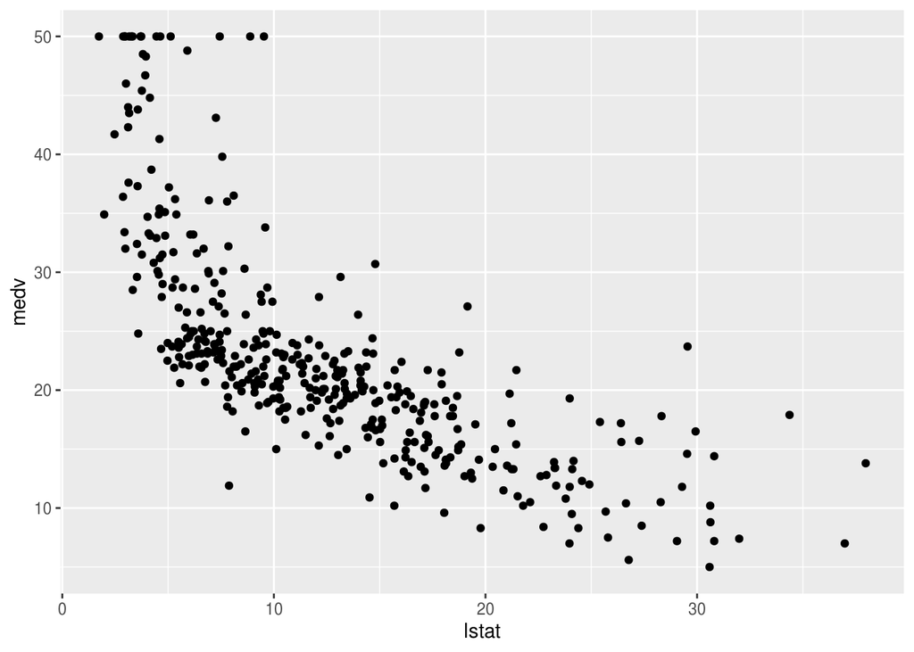

```r
library(ggplot2)
ggplot()+geom_point(data = Boston.train, aes(x = lstat, y = medv))
```

```r
lm.fit=lm(medv~lstat, data=Boston.train)
```

Посмотрим на результат

```r
lm.fit
```

```
##
## Call:
## lm(formula = medv ~ lstat, data = Boston.train)
##
## Coefficients:
## (Intercept)        lstat
##     34.7654      -0.9672
```

Более подробное представление результата

```r
summary(lm.fit)
```

```
##
## Call:
## lm(formula = medv ~ lstat, data = Boston.train)
##
## Residuals:
##     Min      1Q  Median      3Q     Max
## -15.244  -4.110  -1.551   1.845  24.452
##
## Coefficients:
##             Estimate Std. Error t value Pr(>|t|)
## (Intercept) 34.76537    0.65091   53.41   <2e-16 ***
## lstat       -0.96717    0.04574  -21.14   <2e-16 ***
## ---
## Signif. codes:  0 '***' 0.001 '**' 0.01 '*' 0.05 '.' 0.1 ' ' 1
##
## Residual standard error: 6.461 on 403 degrees of freedom
## Multiple R-squared:  0.5259, Adjusted R-squared:  0.5248
## F-statistic: 447.1 on 1 and 403 DF,  p-value: < 2.2e-16
```

Делаем предсказания и считаем ошибки

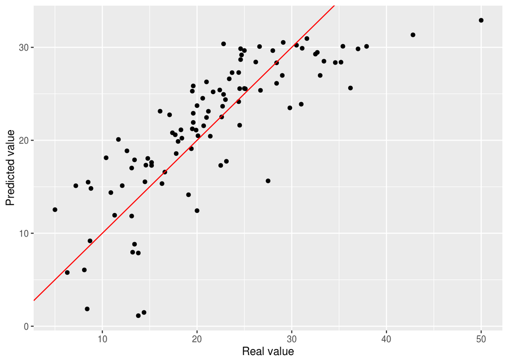

```r
lm.predictions <- predict(lm.fit, Boston.test)

ggplot()+geom_point((aes(x=Boston.test$medv, y=lm.predictions))) +
  geom_abline(color="red") +
  xlab("Real value") +
  ylab("Predicted value")
```

Ошибка предсказания

```r
lm.test.RSS = sum((lm.predictions-Boston.test$medv)^2)
lm.test.RSS
```

```
## [1] 2654.884
```

```r
lm.test.MSE = mean((lm.predictions-Boston.test$medv)^2)
lm.test.MSE
```

```
## [1] 26.28598
```

```r
lm.test.RMSE = sqrt(lm.test.MSE)
lm.test.RMSE
```

```
## [1] 5.126985
```

Переходим к более сложному случаю – когда предикторов несколько (**Multiple Linear Regression**). Например, добавим все переменные

```r
lm.fit=lm(medv~.,data=Boston.train)
summary(lm.fit)
```

```
##
## Call:
## lm(formula = medv ~ ., data = Boston.train)
##
## Residuals:
##     Min      1Q  Median      3Q     Max
## -15.896  -2.778  -0.589   1.528  24.354
##
## Coefficients:
##               Estimate Std. Error t value Pr(>|t|)
## (Intercept)  39.333957   5.829973   6.747 5.46e-11 ***
## crim         -0.068299   0.056748  -1.204 0.229491
## zn            0.054013   0.015223   3.548 0.000435 ***
## indus         0.010441   0.068629   0.152 0.879156
## chas          2.715445   1.016126   2.672 0.007847 **
## nox         -18.176751   4.353078  -4.176 3.67e-05 ***
## rm            3.531637   0.469788   7.518 3.85e-13 ***
## age           0.010707   0.015102   0.709 0.478767
## dis          -1.612945   0.226542  -7.120 5.21e-12 ***
## rad           0.381849   0.079075   4.829 1.97e-06 ***
## tax          -0.015342   0.004320  -3.552 0.000429 ***
## ptratio      -0.980043   0.144038  -6.804 3.83e-11 ***
## black         0.011249   0.003099   3.630 0.000321 ***
## lstat        -0.589025   0.058806 -10.016  < 2e-16 ***
## ---
## Signif. codes:  0 '***' 0.001 '**' 0.01 '*' 0.05 '.' 0.1 ' ' 1
##
## Residual standard error: 4.841 on 391 degrees of freedom
## Multiple R-squared:  0.7418, Adjusted R-squared:  0.7332
## F-statistic: 86.42 on 13 and 391 DF,  p-value: < 2.2e-16
```

**Трансформация предикторов**

Вернемся с простой модели

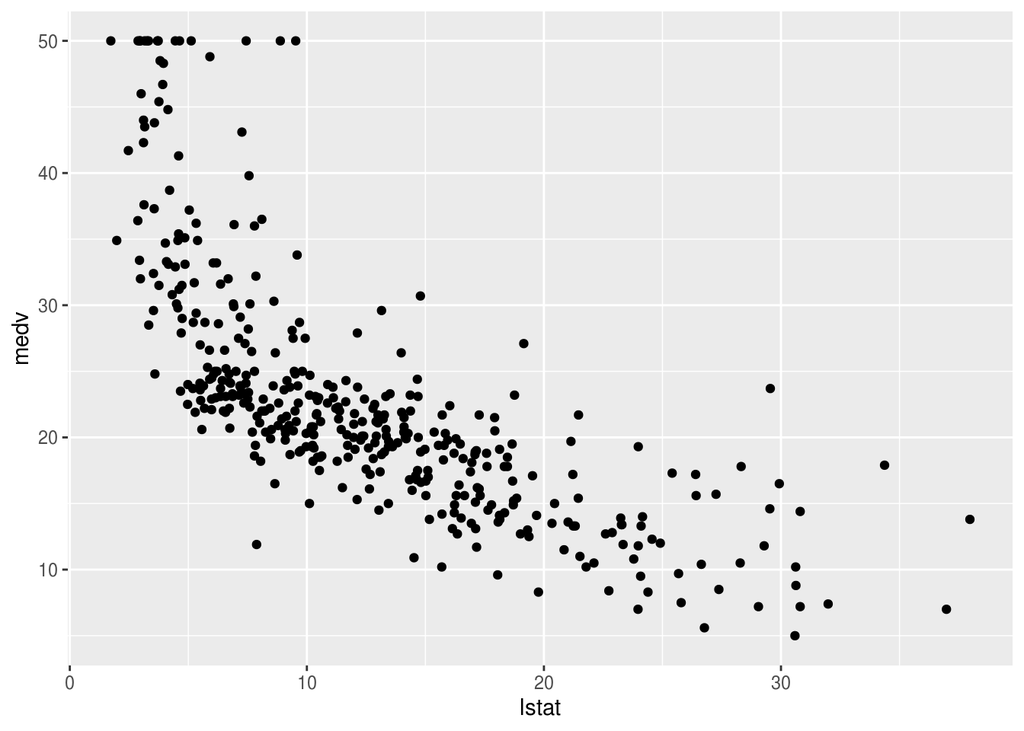

```r
ggplot()+geom_point(data = Boston.train, aes(x = lstat, y = medv))
```

Можно заметить, что зависимость не линейная. Отразим это в модели

```r
lm.fit2=lm(medv~lstat+I(lstat^2), data=Boston.train)
summary(lm.fit2)
```

```
##
## Call:
## lm(formula = medv ~ lstat + I(lstat^2), data = Boston.train)
##
## Residuals:
##      Min       1Q   Median       3Q      Max
## -15.2512  -4.0379  -0.4935   2.4412  25.4933
##
## Coefficients:
##              Estimate Std. Error t value Pr(>|t|)
## (Intercept) 43.230111   1.006827   42.94   <2e-16 ***
## lstat       -2.402445   0.145385  -16.52   <2e-16 ***
## I(lstat^2)   0.045936   0.004467   10.28   <2e-16 ***
## ---
## Signif. codes:  0 '***' 0.001 '**' 0.01 '*' 0.05 '.' 0.1 ' ' 1
##
## Residual standard error: 5.756 on 402 degrees of freedom
## Multiple R-squared:  0.6247, Adjusted R-squared:  0.6228
## F-statistic: 334.6 on 2 and 402 DF,  p-value: < 2.2e-16
```

*Функция I() нужна для того, чтобы действительно произошло воведение в квадрат, т.к. символ ^ в формуле означает пересечение: (a + b)^2 = a + b + a:b*

Сравним с первоначальной моделью на тестовой выборке

```r
lm.predictions2 <- predict(lm.fit2, Boston.test)
lm.test.RSS2 = sum((lm.predictions2-Boston.test$medv)^2)
lm.test.RSS2
```

```
## [1] 2040.337
```

А значение для первоначальной модели было

```r
lm.test.RSS
```

```
## [1] 2654.884
```

- Какая модель лучше с точки зрения качества предсказания?

## Логистическая регрессия

Продолжаем изучать методы. Можно ли применить модель регрессии для решения задачи классификации?

### Данные

Датасет, с которым мы работаем в этой части – результаты диагностики диабета.

```r
library(mlbench)
data(PimaIndiansDiabetes2)
library(dplyr)
Diabetes = na.omit(PimaIndiansDiabetes2)
```

## Регрессия для бинарных предсказаний

Разбиение на тестовую и обучающую

```r
library(caret)
set.seed(100) #You shoud put here your own number
test.ind = createDataPartition(Diabetes$diabetes, p = 0.2, list = FALSE)
Diabetes.test = Diabetes[test.ind,]
Diabetes.main = Diabetes[-test.ind,]
```

diabetes – это фактор (neg/pos).

Давайте немного изменим датасет:

- введем новую переменную `db` = 1, если есть диабет, 0, если нет;
- удалим переменную diabetes (иначе предсказания однозначны)

```r
Diabetes.main2 = mutate(Diabetes.main, db = as.numeric(diabetes=="pos"))
Diabetes.main2 = dplyr::select(Diabetes.main2, -diabetes)
```

Построение линейной модели

```r
lm.model <- lm(db~., data = Diabetes.main2)
summary(lm.model)
```

```
##
## Call:
## lm(formula = db ~ ., data = Diabetes.main2)
##
## Residuals:
##      Min       1Q   Median       3Q      Max
## -0.95231 -0.23774 -0.06822  0.24621  1.05382
##
## Coefficients:
##               Estimate Std. Error t value Pr(>|t|)
## (Intercept) -1.048e+00  1.568e-01  -6.682 1.13e-10 ***
## pregnant     1.856e-02  9.188e-03   2.020  0.04428 *
## glucose      6.678e-03  8.878e-04   7.522 6.15e-13 ***
## pressure     1.242e-04  1.832e-03   0.068  0.94601
## triceps      2.564e-03  2.692e-03   0.953  0.34147
## insulin      5.183e-07  2.345e-04   0.002  0.99824
## mass         6.276e-03  4.205e-03   1.493  0.13658
## pedigree     2.655e-01  6.813e-02   3.896  0.00012 ***
## age          2.648e-03  3.043e-03   0.870  0.38477
## ---
## Signif. codes:  0 '***' 0.001 '**' 0.01 '*' 0.05 '.' 0.1 ' ' 1
##
## Residual standard error: 0.3793 on 304 degrees of freedom
## Multiple R-squared:  0.3701, Adjusted R-squared:  0.3536
## F-statistic: 22.33 on 8 and 304 DF,  p-value: < 2.2e-16
```

Посмотрим на соответствие реальных и предсказанных значений

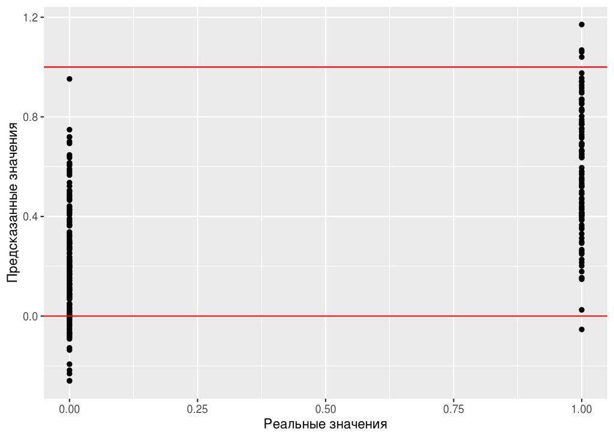

```r
ggplot() + geom_point(aes(x=Diabetes.main2$db, y = predict(lm.model, Diabetes.main2))) +
  geom_hline(yintercept = c(0,1), color = "red") +
  xlab("Реальные значения")+
  ylab("Предсказанные значения")
```

Как делать выводы о наличии или отсутствии диабета? Т.е. если значения от 0 до 1 еще можно было попробовать обосновать как некую “вероятность”, то что делать со значениями, попадающими сильно за эти пределы

Но аппарат регрессии все равно использовать хочется. Выход был найден следующий: давайте предсказывать не само значение, а вероятность попадания в класс = 1. Раз это вероятность, то она должна быть в промежутке от 0 до 1. Преобразуем немного наше значение с помощью сигмоидной функции – какое бы значение мы ни использовали в Input, Output будет от 0 до 1. Формула для сигмоидной функции $f(x)=e^x/(e^x+1)$.

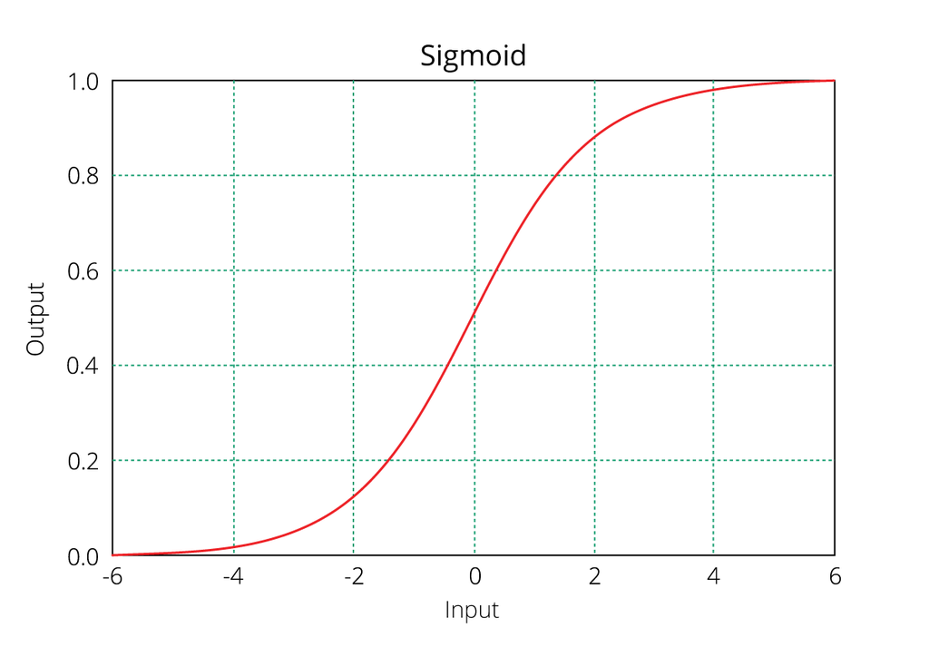

В контексте регрессии получаем (для любителей формул)

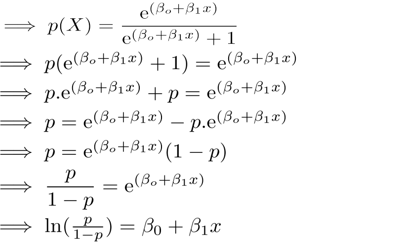

А отсюда получаем и интепретацию коэффициентов регрессии: увеличение значения на 1 приводит к увеличению шансов в $e^{коэффициент}$ раз.

## Построение модели

Теперь к тому, как получить логистическую регрессию в R (работает и с факторами!)

```r
log.model = glm(diabetes~., data = Diabetes.main, family = binomial(link = 'logit'))
summary(log.model)
```

```
##
## Call:
## glm(formula = diabetes ~ ., family = binomial(link = "logit"),
##     data = Diabetes.main)
##
## Deviance Residuals:
##     Min       1Q   Median       3Q      Max
## -2.4670  -0.6225  -0.3443   0.5740   2.6346
##
## Coefficients:
##               Estimate Std. Error z value Pr(>|z|)
## (Intercept) -9.9447862  1.3634157  -7.294 3.01e-13 ***
## pregnant     0.1272019  0.0635367   2.002 0.045282 *
## glucose      0.0408512  0.0065481   6.239 4.41e-10 ***
## pressure    -0.0010775  0.0132122  -0.082 0.935003
## triceps      0.0163886  0.0187555   0.874 0.382227
## insulin      0.0001038  0.0014717   0.071 0.943758
## mass         0.0535938  0.0306591   1.748 0.080455 .
## pedigree     1.8725387  0.5159161   3.630 0.000284 ***
## age          0.0127843  0.0206773   0.618 0.536393
## ---
## Signif. codes:  0 '***' 0.001 '**' 0.01 '*' 0.05 '.' 0.1 ' ' 1
##
## (Dispersion parameter for binomial family taken to be 1)
##
##     Null deviance: 397.99  on 312  degrees of freedom
## Residual deviance: 264.94  on 304  degrees of freedom
## AIC: 282.94
##
## Number of Fisher Scoring iterations: 5
```

```r
log.model2 = glm(db~., data = Diabetes.main2, family = binomial(link = 'logit'))
summary(log.model2)
```

```
##
## Call:
## glm(formula = db ~ ., family = binomial(link = "logit"), data = Diabetes.main2)
##
## Deviance Residuals:
##     Min       1Q   Median       3Q      Max
## -2.4670  -0.6225  -0.3443   0.5740   2.6346
##
## Coefficients:
##               Estimate Std. Error z value Pr(>|z|)
## (Intercept) -9.9447862  1.3634157  -7.294 3.01e-13 ***
## pregnant     0.1272019  0.0635367   2.002 0.045282 *
## glucose      0.0408512  0.0065481   6.239 4.41e-10 ***
## pressure    -0.0010775  0.0132122  -0.082 0.935003
## triceps      0.0163886  0.0187555   0.874 0.382227
## insulin      0.0001038  0.0014717   0.071 0.943758
## mass         0.0535938  0.0306591   1.748 0.080455 .
## pedigree     1.8725387  0.5159161   3.630 0.000284 ***
## age          0.0127843  0.0206773   0.618 0.536393
## ---
## Signif. codes:  0 '***' 0.001 '**' 0.01 '*' 0.05 '.' 0.1 ' ' 1
##
## (Dispersion parameter for binomial family taken to be 1)
##
##     Null deviance: 397.99  on 312  degrees of freedom
## Residual deviance: 264.94  on 304  degrees of freedom
## AIC: 282.94
##
## Number of Fisher Scoring iterations: 5
```

## Еще раз про метрики

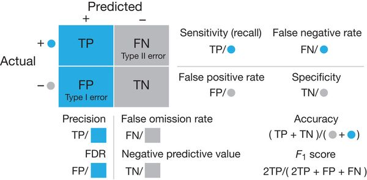

Посмотрим на предсказание. Напомню – предсказываем вероятность. Как по этим значениям отнести к тому или иному классу?

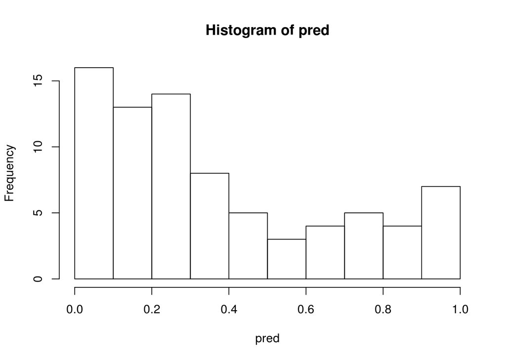

```r
pred = predict(log.model, newdata = Diabetes.test, type = "response")
hist(pred)
```

**Обратите внимание**: по умолчанию выдается не вероятность, а значение функции. Которая, правда, легко преобразуется в вероятность подстановкой в сигмоидную функцию

```r
predLink = predict(log.model, newdata = Diabetes.test)
head(predLink)
```

```
##         64         89        106        138        140        145
## -0.4453441  0.8039917 -0.9331049 -2.9754195 -1.9546614 -0.1784564
```

```r
head(exp(predLink)/(exp(predLink)+1))
```

```
##         64         89        106        138        140        145
## 0.39046831 0.69082769 0.28229523 0.04854877 0.12404597 0.45550393
```

Значение классов можем определить, задав границу разделения

```r
pred0.5 <- ifelse(pred > 0.5,"pos","neg")
head(pred0.5)
```

```
##    64    89   106   138   140   145
## "neg" "pos" "neg" "neg" "neg" "neg"
```

```r
caret::confusionMatrix(pred0.5, Diabetes.test$diabetes)
```

```
## Confusion Matrix and Statistics
##
##           Reference
## Prediction neg pos
##        neg  46  10
##        pos   7  16
##
##                Accuracy : 0.7848
##                  95% CI : (0.678, 0.8694)
##     No Information Rate : 0.6709
##     P-Value [Acc > NIR] : 0.01829
##
##                   Kappa : 0.4979
##  Mcnemar's Test P-Value : 0.62763
##
##             Sensitivity : 0.8679
##             Specificity : 0.6154
##          Pos Pred Value : 0.8214
##          Neg Pred Value : 0.6957
##              Prevalence : 0.6709
##          Detection Rate : 0.5823
##    Detection Prevalence : 0.7089
##       Balanced Accuracy : 0.7417
##
##        'Positive' Class : neg
##
```

А если поменять границу?

```r
pred0.7 <- ifelse(pred > 0.7,"pos","neg")
caret::confusionMatrix(pred0.7, Diabetes.test$diabetes)
```

```
## Confusion Matrix and Statistics
##
##           Reference
## Prediction neg pos
##        neg  48  15
##        pos   5  11
##
##                Accuracy : 0.7468
##                  95% CI : (0.6364, 0.838)
##     No Information Rate : 0.6709
##     P-Value [Acc > NIR] : 0.09194
##
##                   Kappa : 0.3644
##  Mcnemar's Test P-Value : 0.04417
##
##             Sensitivity : 0.9057
##             Specificity : 0.4231
##          Pos Pred Value : 0.7619
##          Neg Pred Value : 0.6875
##              Prevalence : 0.6709
##          Detection Rate : 0.6076
##    Detection Prevalence : 0.7975
##       Balanced Accuracy : 0.6644
##
##        'Positive' Class : neg
##
```

Как выбрать? Более того, если у нас несколько подобных моделей, то как узнать, какая модель лучше?

## ROC & AUC

Метрики оценки качества в этом случае

- ROC-кривая (Receiver Operating Characteristic) – график, показывающий соотношение между долей объектов от общего количества носителей признака, верно классифицированных как несущих признак, (true positive rate, TPR, sensitivity, чувствительность алгоритма классификации) и долей объектов от общего количества объектов, не несущих признака, ошибочно классифицированных как несущих признак (англ. false positive rate, FPR, 1-FPR = specificity, специфичность алгоритма классификации) при разных значениях границы, разделяющей классы
- AUC (Area Under ROC Curve) – площадь под этой кривой

```r
library(pROC)
```

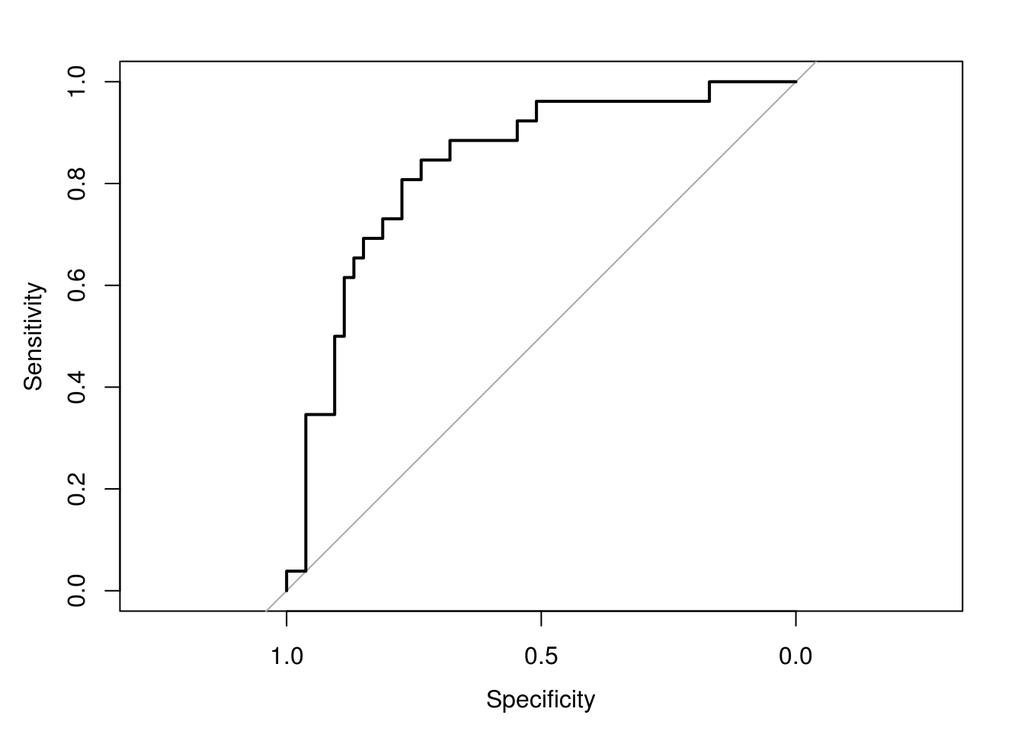

```r
ROCfull = roc(response = Diabetes.test$diabetes, predictor = pred)
plot(ROCfull)
```

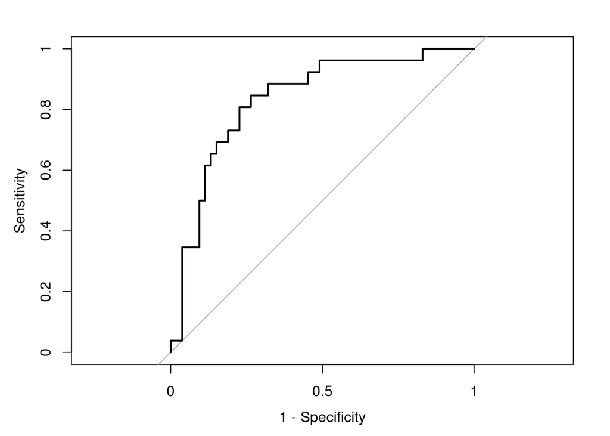

```r
plot(ROCfull, legacy.axes=T)
```

```r
pROC::auc(ROCfull)
```

```
## Area under the curve: 0.8345
```

Можно использовать не весь объект, а отдельно specificity и sensitivity и построить ROC с помощью, например, ggplot2

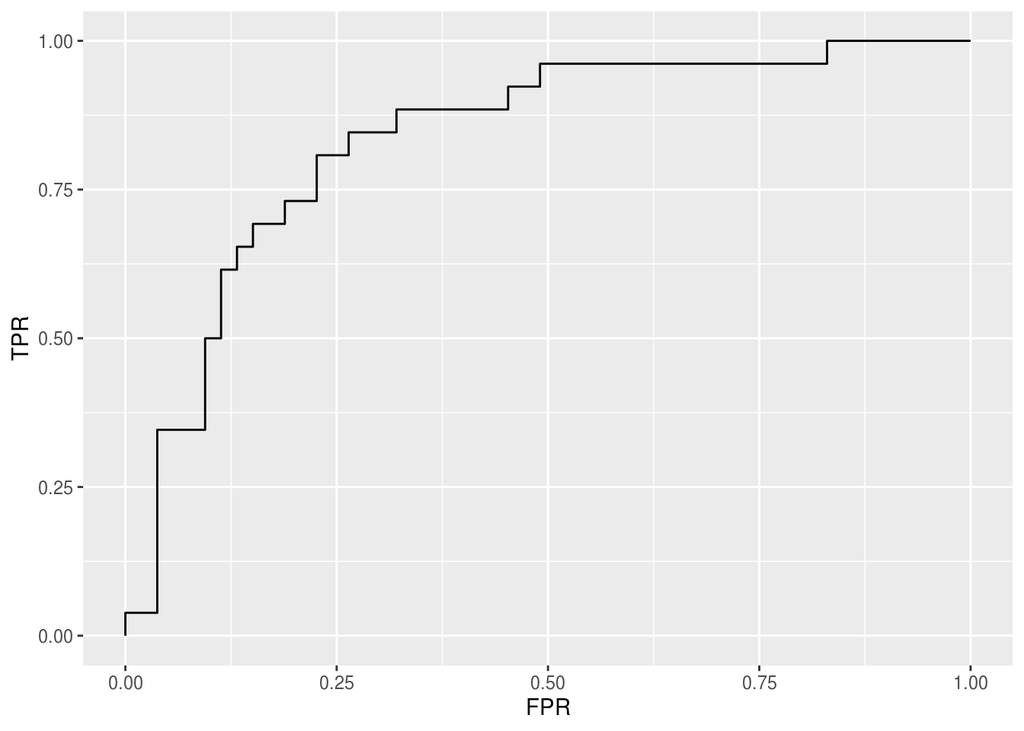

```r
ggplot() + geom_path(aes(y=ROCfull$sensitivities, x=1-ROCfull$specificities))+
  xlab("FPR") + ylab("TPR")
```

Построим еще одну модель

```r
log.modelSmall = glm(diabetes~age, data = Diabetes.main, family = binomial(link = 'logit'))
summary(log.modelSmall)
```

```
##
## Call:
## glm(formula = diabetes ~ age, family = binomial(link = "logit"),
##     data = Diabetes.main)
##
## Deviance Residuals:
##     Min       1Q   Median       3Q      Max
## -2.4183  -0.7757  -0.6611   1.0699   1.8368
##
## Coefficients:
##             Estimate Std. Error z value Pr(>|z|)
## (Intercept) -3.00495    0.42386  -7.090 1.35e-12 ***
## age          0.07252    0.01261   5.752 8.81e-09 ***
## ---
## Signif. codes:  0 '***' 0.001 '**' 0.01 '*' 0.05 '.' 0.1 ' ' 1
##
## (Dispersion parameter for binomial family taken to be 1)
##
##     Null deviance: 397.99  on 312  degrees of freedom
## Residual deviance: 359.82  on 311  degrees of freedom
## AIC: 363.82
##
## Number of Fisher Scoring iterations: 4
```

```r
predSmall = predict(log.modelSmall, newdata = Diabetes.test, type = "response")

log.modelPressure = glm(diabetes~pressure, data = Diabetes.main, family = binomial(link = 'logit'))
predPres = predict(log.modelPressure, newdata = Diabetes.test, type = "response")
```

```r
ROCsmall = roc(response = Diabetes.test$diabetes, predictor = predSmall)
pROC::auc(ROCsmall)
```

```
## Area under the curve: 0.7286
```

```r
ROCpres = roc(response = Diabetes.test$diabetes, predictor = predPres)
pROC::auc(ROCpres)
```

```
## Area under the curve: 0.6702
```

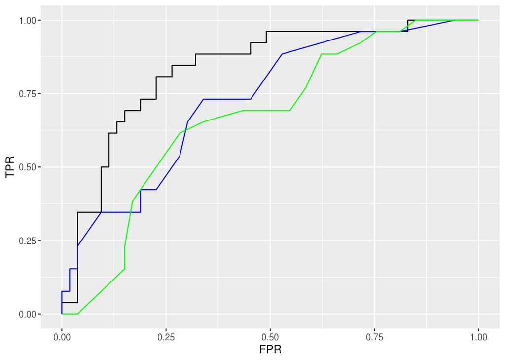

```r
ggplot() + geom_path(aes(y=ROCfull$sensitivities, x=1-ROCfull$specificities)) +
  geom_path(aes(y=ROCsmall$sensitivities, x=1-ROCsmall$specificities), color = "blue") +
  geom_path(aes(y=ROCpres$sensitivities, x=1-ROCpres$specificities), color = "green") +

  xlab("FPR") + ylab("TPR")
```

Какая модель лучше?

**Ваша очередь:**

Данные про успешность поста в Facebook на странице конкретного бренда. Последние 7 переменных – показатели успешности поста:

- UniqueViews - число уникальных пользователей, посмотревших пост
- UniqueClicks - число уникальных пользователей, кликнувших где-то на посте
- UniqueViewsFollowers - число уникальных пользователей из числа подписчиков, посмотревших пост
- UniqueClicksFollowers - число уникальных пользователей из числа подписчиков, кликнувших где-то на посте

Посчитайте отношение числа лайков к числу пользователей, кликнувших на посте (like / UniqueClicks). Предскажите посты, у которых этот показатель больше 15%. При вычислениях подумайте, нужно ли как-то преобразовывать предикторы (месяц, день, час категория публикации) – объединять в группы, преобразовать в факторы и т.д.

```r
library(dplyr)
fb= read.csv("Facebook.csv")
```

Постройте модели для предсказания других метрик успешности.